# DETECTR 050 SpectraMax AMP and UMP Data - NANCY DREW

## AMP NEBuffer 4 + 2.1 Fresh Standard Curves for concentrations from 0.01uM to 10uM, including 0uM

- 0hr and 1hr single time points are first two plots
- Summation of all data points below 1hr is the last plot
- Fresh Standard Curve with no ATP

### Conclusion

Same as before - 1hr looks better than 0hr. Summing doesn’t help with whole regression.

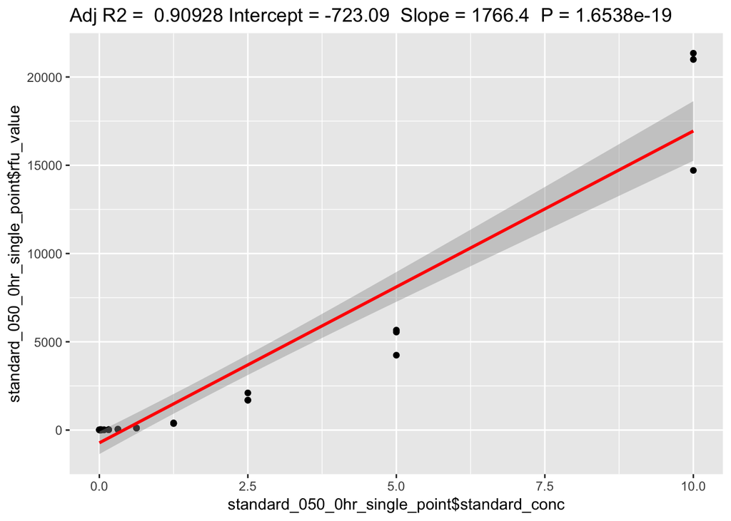

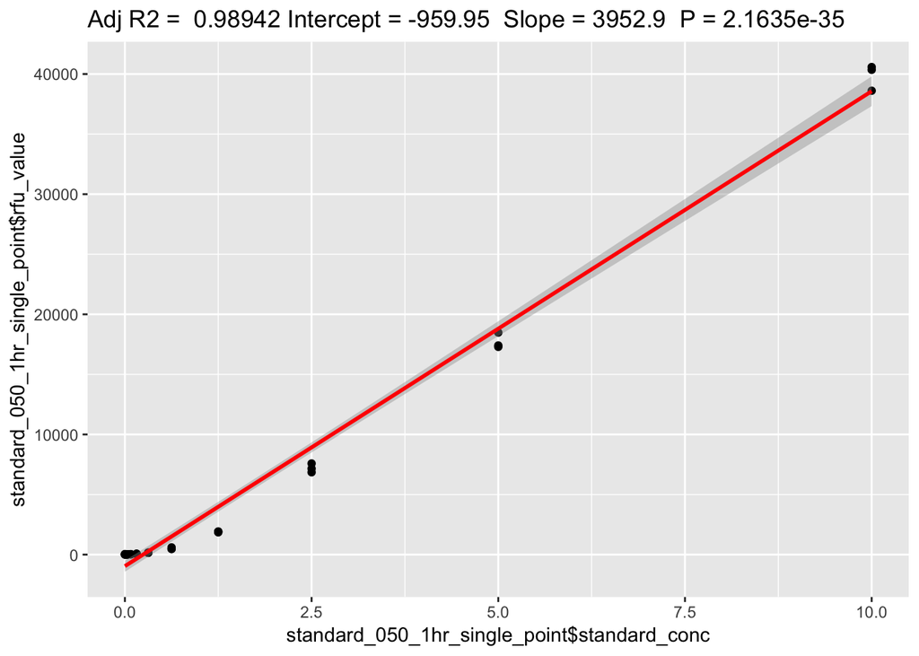

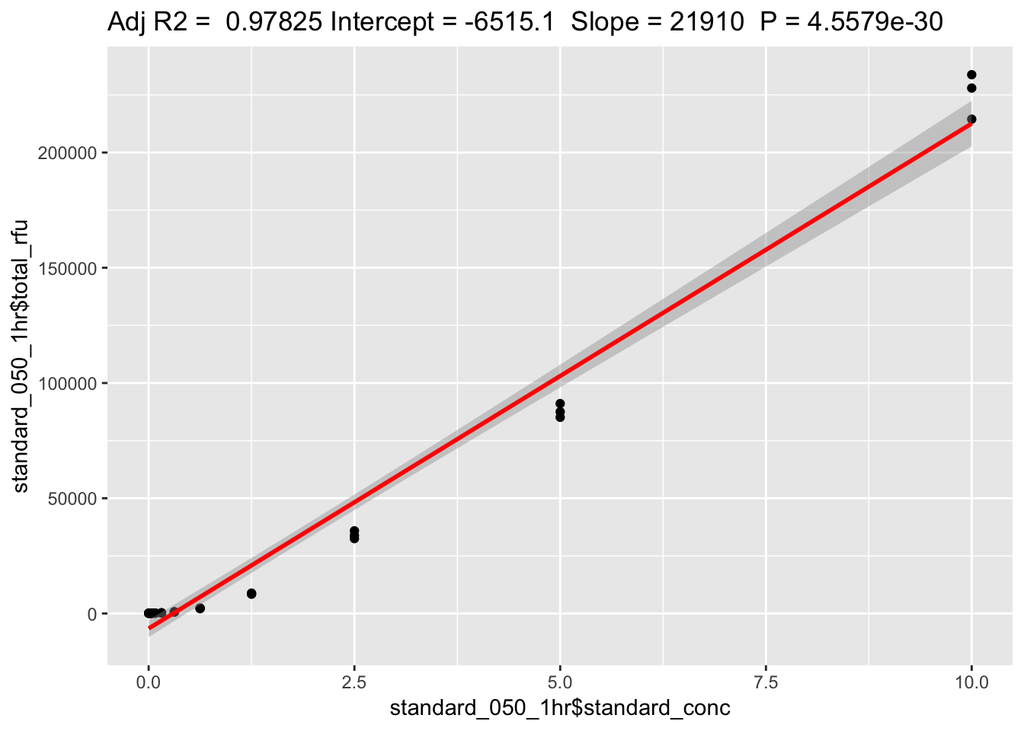

## AMP NEBuffer 4+ 2.1 Fresh Standard Curves for concentrations from 0.01uM to 0.16uM, including 0uM

- 0hr and 1hr single time points are first two plots
- Summation of all data points below 1hr is the last plot
- Fresh Standard Curve with no ATP

### Conclusion

Same as before - summing reduces noise quite a bit. Can detect down to 0.08 uM with summing.

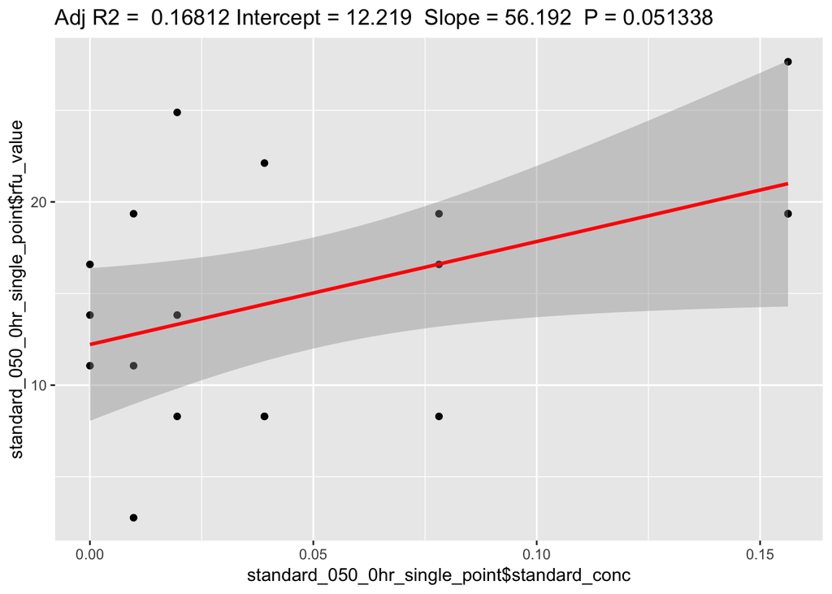

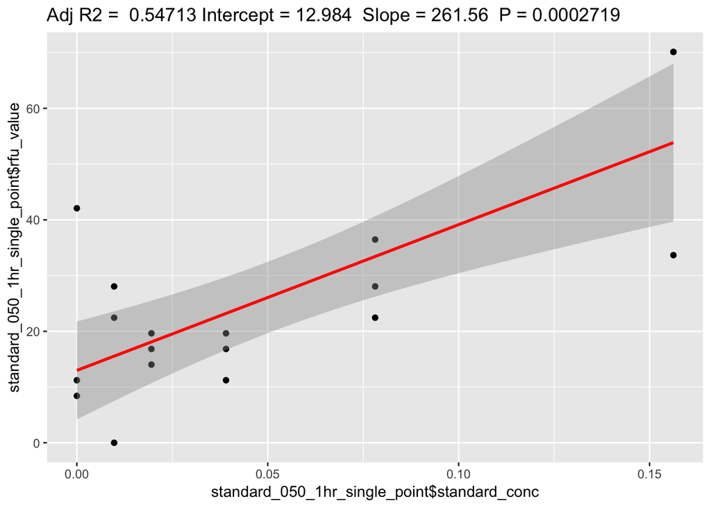

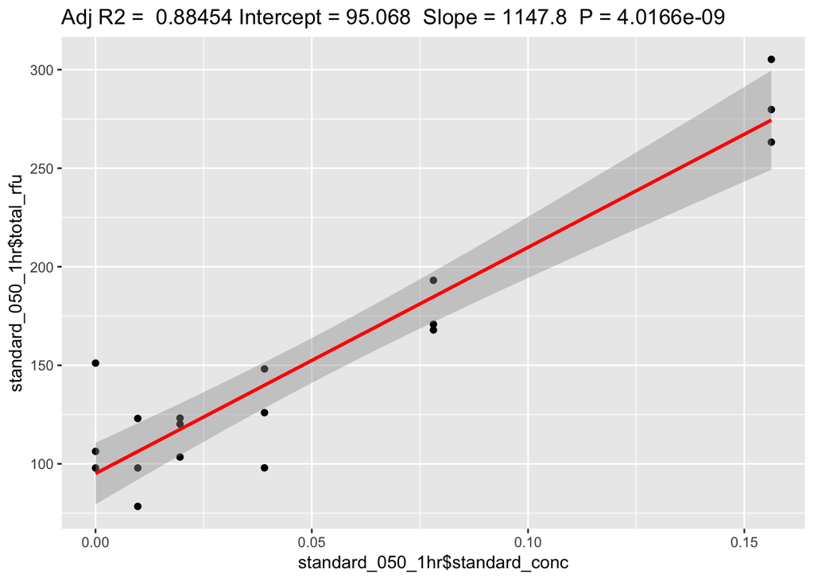

## UMP NEBuffer 4 + 2.1 Fresh Standard Curves for concentrations from 0.01uM to 10uM, including 0uM

- 0hr and 1hr single time points are first two plots
- Summation of all data points below 1hr is the last plot
- Fresh Standard Curve

### Conclusion

UMP standard curve looks a lot better than AMP across the entire range. 1 hr is better than 0 hr. Summing reduces noise.

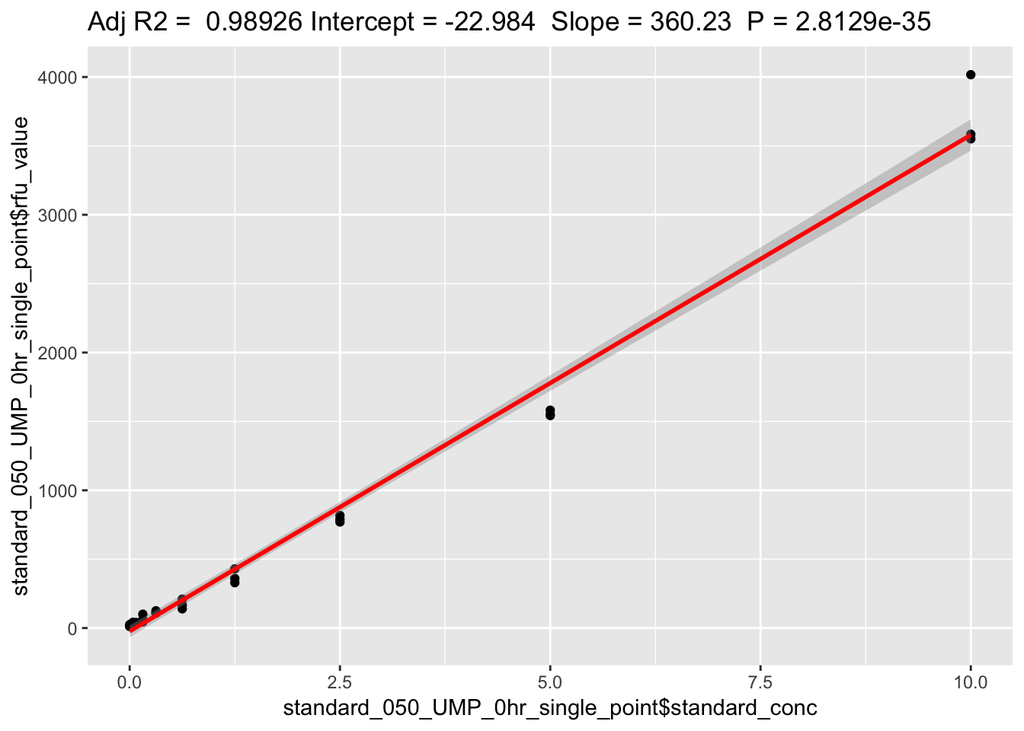

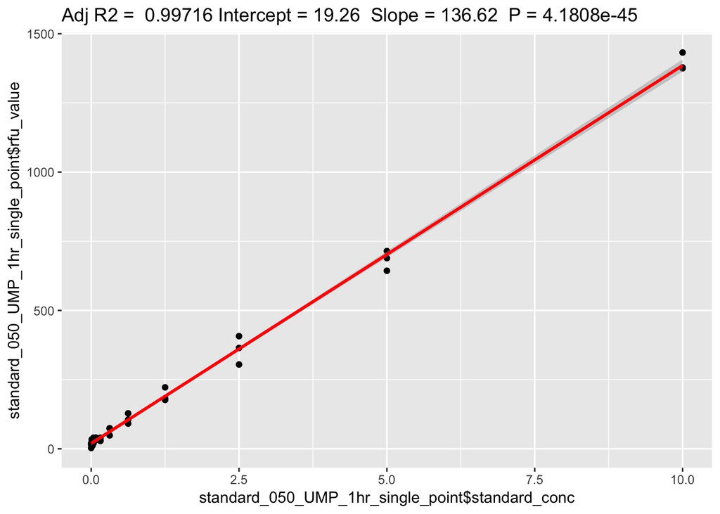

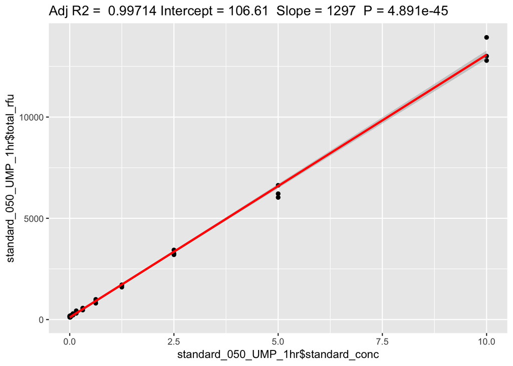

- 0hr and 1hr single time points are first two plots
- Summation of all data points below 1hr is the last plot
- Fresh Standard Curve

### Conclusion

Summing significantly helps with lower concentrations. Can MAYBE detect down to 0.04uM. This is the same as DETECTR 043.

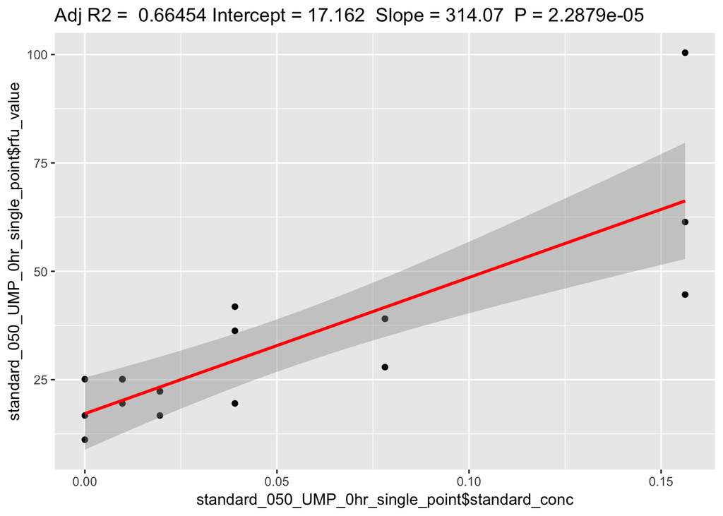

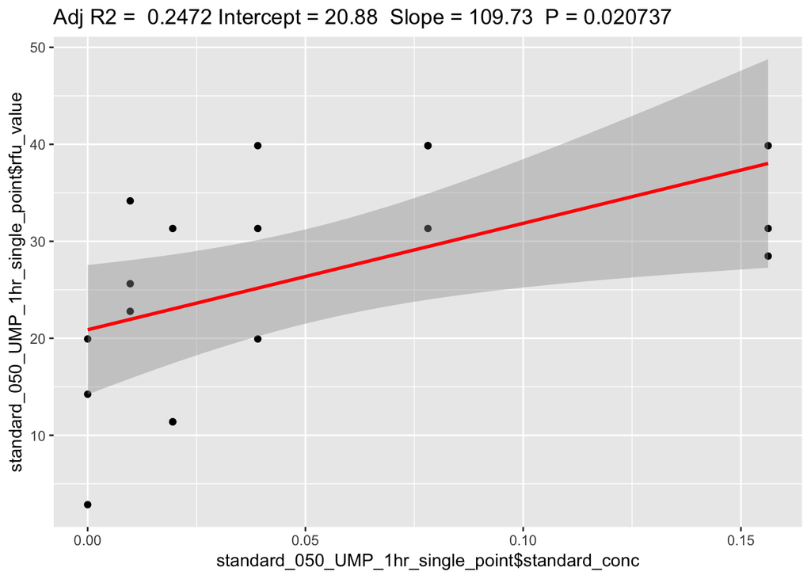

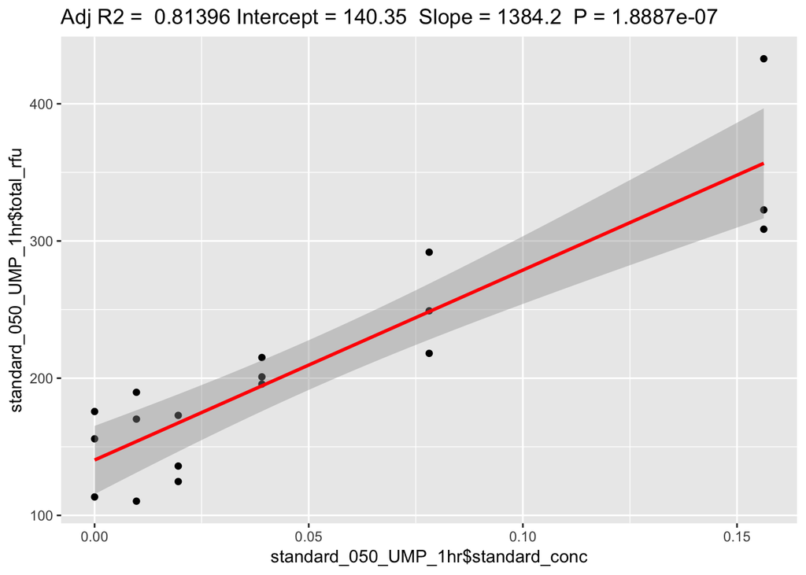

## Background for AMP vs UMP GLO NANCY DREW

- Used NEB cas12a and synthetic 11C gRNA with synthetic 11C target for all
- All AMP samples had the r17Ar3C and UMP samples had the r17U-TTATT-phos reporter
- AMP background was done on Wednesday and UMP background was done on Thursday.
- RFU values were converted to AMP or UMP uM concentrations using the 1hr summation regression

### Conclusions

Both don’t seem to have a ton of background from either bacterial or human gDNA. UMP appears to have a slightly concentration dependent response to human gDNA. UMP also has a higher signal to noise ratio. They both have a similar noise level but AMP signal is lower. Of note, AMP reporter contained no DNA (r17Ar3C) and UMP reporter did (r17U-TTATT-phos).

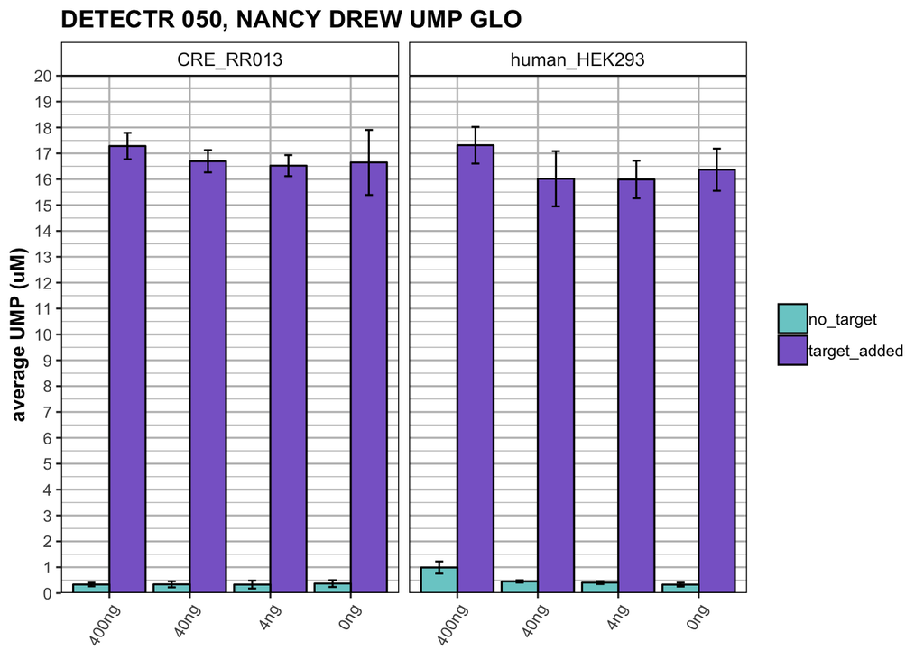

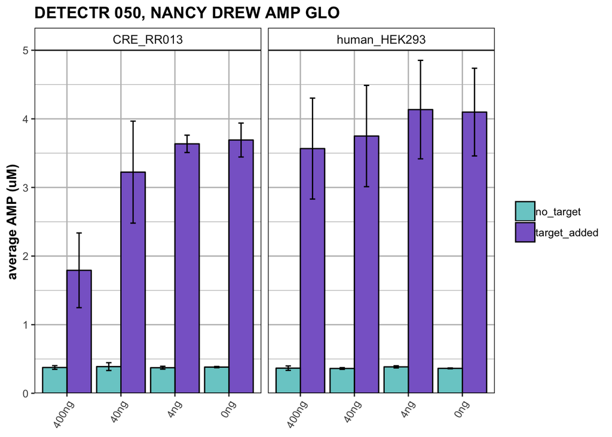

## UMP and AMP compared

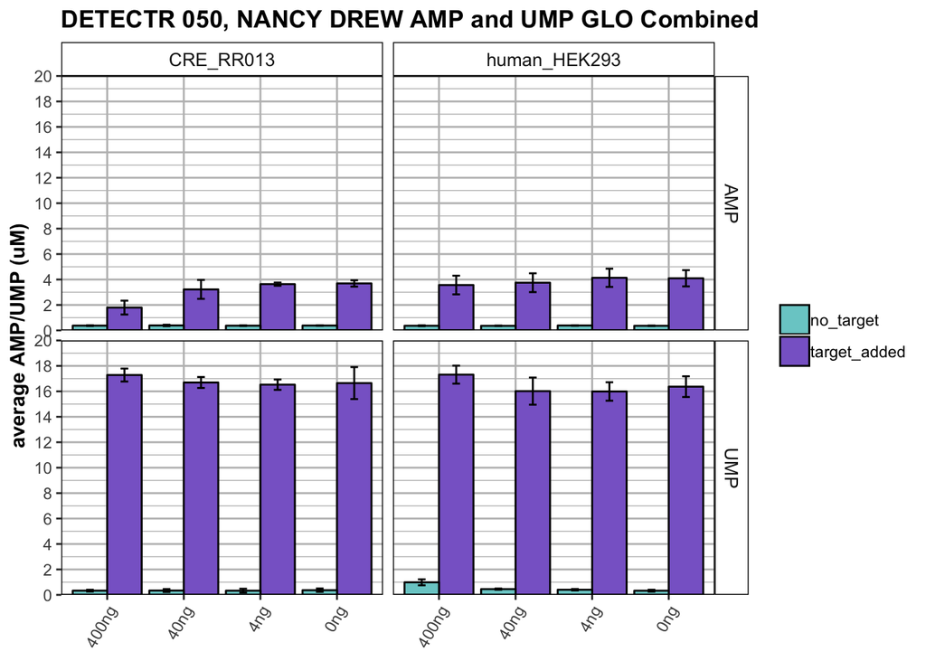

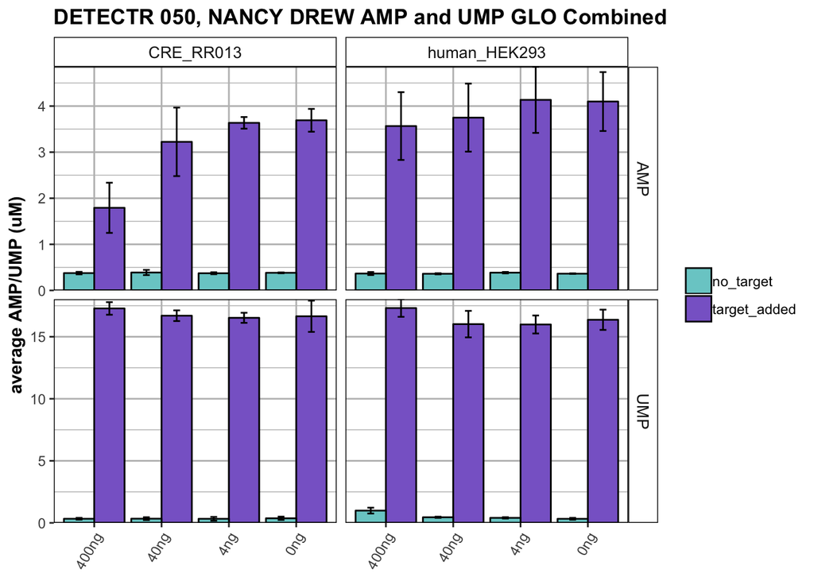

## TB Insertion Sequences alt-R synthetic gRNAs

- This experiment was done in duplicate
- Synthetic alt-R gRNAs were diluted to 35.2ng/uL based on Qubit rather than molar calculations from IDT
- Transcribed IS1081 has been tested extensively in FRET assay, but transcribed IS6110 was only tested once and gave low signal

### Conclusions

IS6110 gRNA didn’t work, perhaps because it is not a great gRNA as illustrated in DETECTR_004. IS1081 worked, but gave a low signal for unknown reasons - weak gRNA? gRNA concentration? DNA age? All negative controls, including the mismatched target DNA to the gRNA, turned up negative.

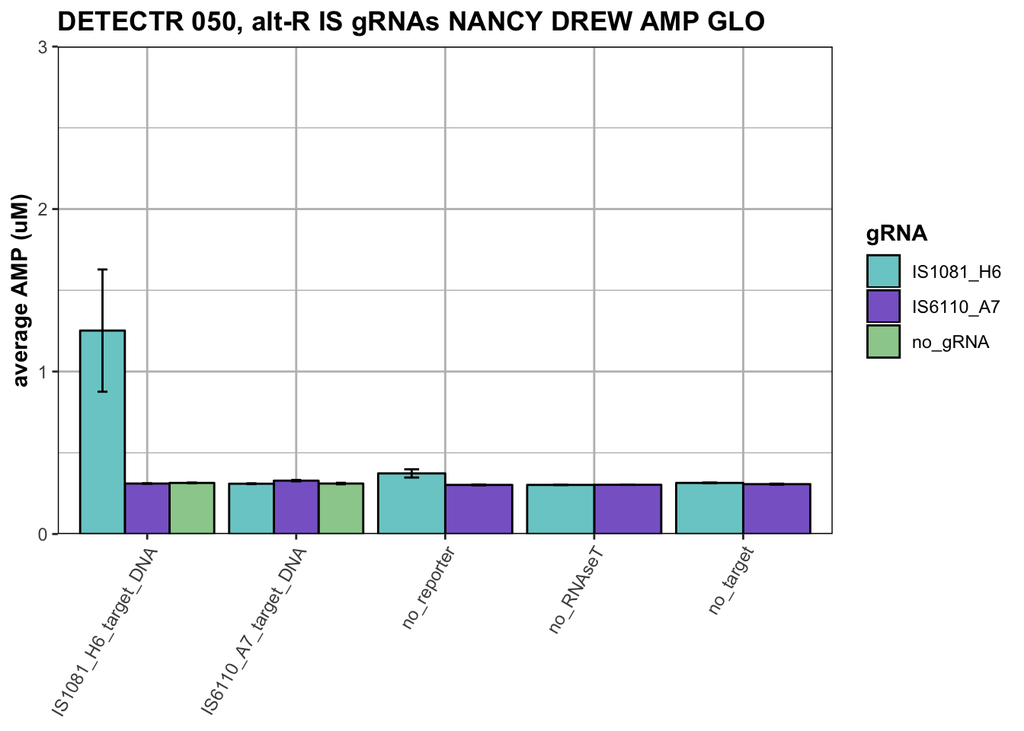

## Background UMP GLO Data with wrong reporter

- On the day I did the AMP GLO experiment, I added the wrong reporter for the UMP GLO samples - r17Ar3C instead of a U based reporter
- I took the experiment to completion as a negative control

### Conclusions

UMP still looks like it might be getting some background signal from human gDNA. Having the wrong reporter gives no signal in target added condition.

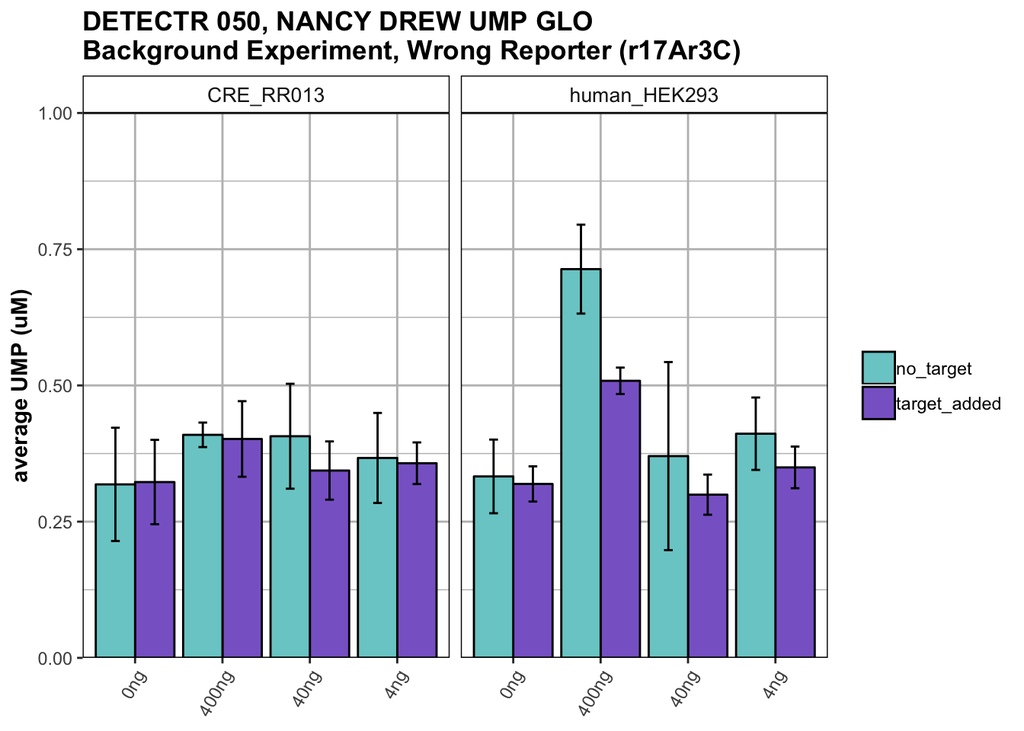

## Kinetics over time, UMP and AMP standards

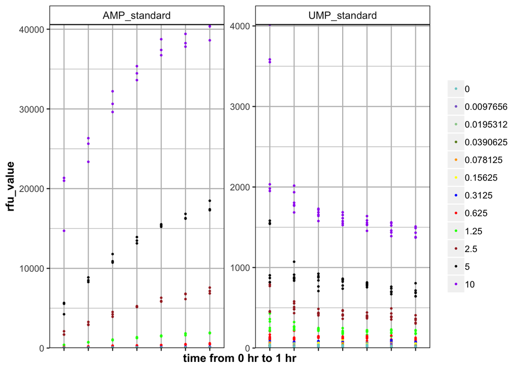